# Problem Set 1

### Before You Start

For this problem set, you should download flights.csv.bz2 and weather.csv.bz2 datasets from Canvas (files-data). Rename the notebook to LASTNAME_FIRSTNAME-PS1.ipynb.

When done, please submit

1. the notebook itself
2. the rendered html or pdf of it.

Note: you do not have to use notebooks to solve this PS. However, you have to submit

- your code
- your results
- your explanations whatever means you use to solve this assignment.

It is all fine to discuss the problems and way how to solve these with your classmates and instructors. However, the solutions must be your own. Don't copy-paste each other solutions!

## About the Problem Set:

This problem set is rather similar to ones used for R, dplyr, and flights data. Just we use python and pandas.

Your task is to analyze the nycflights13 data (in the R package of the same name). The necessary csv files are provided on canvas (in files/data). An easy way to get the explanations is on the the [package page on R documentation](https://www.rdocumentation.org/packages/nycflights13/versions/1.0.0).

In this problem set you will perform a basic exploratory analysis on an example dataset, bringing to bear all of your new skills in data manipulation and visualization. You will be required to submit well commented python code, documenting all code used in this problem set, along with a write up answering all questions below. Use figures as appropriate to support your answers, and when required by the problem.

Always comment your results, preferably in a separate markdown cell.

## Preliminaries

You should also make sure the following libraries load correctly. Below are a few basic data description tasks already done for you.

```python
#IPython is what you are using now to run the notebook
import IPython
print( "IPython version:      %6.6s (need at least 1.0)" % IPython.__version__)

# Numpy is a library for working with arrays and matrices
import numpy as np
print( "Numpy version:        %6.6s (need at least 1.7.1)" % np.__version__)

# SciPy implements many different numerical algorithms
import scipy as sp
print( "SciPy version:        %6.6s (need at least 0.12.0)" % sp.__version__)

# Pandas makes working with data tables easier
import pandas as pd
print( "Pandas version:       %6.6s (need at least 0.11.0)" % pd.__version__)

# Module for plotting
import matplotlib.pyplot as plt
from pylab import *
print( "Mapltolib version:    %6.6s (need at least 1.2.1)" %
       matplotlib.__version__)
%matplotlib inline
# necessary for in-line graphics

# SciKit Learn implements several Machine Learning algorithms
import sklearn
print( "Scikit-Learn version: %6.6s (need at least 0.13.1)" %
       sklearn.__version__)
import os
# for certain system-related functions
```

```
IPython version:       7.8.0 (need at least 1.0)
Numpy version:        1.16.5 (need at least 1.7.1)
SciPy version:         1.3.1 (need at least 0.12.0)
Pandas version:       0.25.1 (need at least 0.11.0)
Mapltolib version:     3.1.1 (need at least 1.2.1)
Scikit-Learn version: 0.21.3 (need at least 0.13.1)
```

```python
## Let's read the data and print some summary information
## adjust the path for your file system!
## you can find the path like this:
path = os.getcwd()
print(path)
flights_df= pd.read_csv('C:/Users/vaide/Documents/574-DS2/flights.csv.bz2')
```

```
C:\Users\vaide\Documents\574-DS2
```

```python
## Extract some basic information about the data like number of rows,
## columns, column names, data types
print(flights_df.shape)
print(flights_df.columns)
print(flights_df.dtypes)
```

```
(336776, 17)
Index(['Unnamed: 0', 'year', 'month', 'day', 'dep_time', 'dep_delay',
       'arr_time', 'arr_delay', 'carrier', 'tailnum', 'flight', 'origin',
       'dest', 'air_time', 'distance', 'hour', 'minute'],
      dtype='object')
Unnamed: 0      int64
year            int64
month           int64
day             int64
dep_time      float64
dep_delay     float64
arr_time      float64
arr_delay     float64
carrier        object
tailnum        object
flight          int64
origin         object
dest           object
air_time      float64
distance        int64
hour          float64
minute        float64
dtype: object
```

```python
## print the first and last few lines of the data
print("head\n", flights_df.head())
print("tail\n", flights_df.tail())
## Find the number of unique destinations in the data ('dest')
print("destinations:\n", flights_df.dest.unique())
print("destinations:\n", flights_df.origin.unique())
```

```
head
    Unnamed: 0  year  month  day  dep_time  dep_delay  arr_time  arr_delay  \
0           1  2013      1    1     517.0        2.0     830.0       11.0
1           2  2013      1    1     533.0        4.0     850.0       20.0
2           3  2013      1    1     542.0        2.0     923.0       33.0
3           4  2013      1    1     544.0       -1.0    1004.0      -18.0
4           5  2013      1    1     554.0       -6.0     812.0      -25.0

  carrier tailnum  flight origin dest  air_time  distance  hour  minute
0      UA  N14228    1545    EWR  IAH     227.0      1400   5.0    17.0
1      UA  N24211    1714    LGA  IAH     227.0      1416   5.0    33.0
2      AA  N619AA    1141    JFK  MIA     160.0      1089   5.0    42.0
3      B6  N804JB     725    JFK  BQN     183.0      1576   5.0    44.0
4      DL  N668DN     461    LGA  ATL     116.0       762   5.0    54.0
tail
         Unnamed: 0  year  month  day  dep_time  dep_delay  arr_time  \
336771      336772  2013      9   30       NaN        NaN       NaN
336772      336773  2013      9   30       NaN        NaN       NaN
336773      336774  2013      9   30       NaN        NaN       NaN
336774      336775  2013      9   30       NaN        NaN       NaN
336775      336776  2013      9   30       NaN        NaN       NaN

        arr_delay carrier tailnum  flight origin dest  air_time  distance  \
336771        NaN      9E     NaN    3393    JFK  DCA       NaN       213
336772        NaN      9E     NaN    3525    LGA  SYR       NaN       198
336773        NaN      MQ  N535MQ    3461    LGA  BNA       NaN       764
336774        NaN      MQ  N511MQ    3572    LGA  CLE       NaN       419
336775        NaN      MQ  N839MQ    3531    LGA  RDU       NaN       431

        hour  minute
336771   NaN     NaN
336772   NaN     NaN
336773   NaN     NaN
336774   NaN     NaN
336775   NaN     NaN
destinations:
 ['IAH' 'MIA' 'BQN' 'ATL' 'ORD' 'FLL' 'IAD' 'MCO' 'PBI' 'TPA' 'LAX' 'SFO'
 'DFW' 'BOS' 'LAS' 'MSP' 'DTW' 'RSW' 'SJU' 'PHX' 'BWI' 'CLT' 'BUF' 'DEN'
 'SNA' 'MSY' 'SLC' 'XNA' 'MKE' 'SEA' 'ROC' 'SYR' 'SRQ' 'RDU' 'CMH' 'JAX'
 'CHS' 'MEM' 'PIT' 'SAN' 'DCA' 'CLE' 'STL' 'MYR' 'JAC' 'MDW' 'HNL' 'BNA'
 'AUS' 'BTV' 'PHL' 'STT' 'EGE' 'AVL' 'PWM' 'IND' 'SAV' 'CAK' 'HOU' 'LGB'
 'DAY' 'ALB' 'BDL' 'MHT' 'MSN' 'GSO' 'CVG' 'BUR' 'RIC' 'GSP' 'GRR' 'MCI'
 'ORF' 'SAT' 'SDF' 'PDX' 'SJC' 'OMA' 'CRW' 'OAK' 'SMF' 'TUL' 'TYS' 'OKC'
 'PVD' 'DSM' 'PSE' 'BHM' 'CAE' 'HDN' 'BZN' 'MTJ' 'EYW' 'PSP' 'ACK' 'BGR'
 'ABQ' 'ILM' 'MVY' 'SBN' 'LEX' 'CHO' 'TVC' 'ANC' 'LGA']
destinations:
 ['EWR' 'LGA' 'JFK']
```

## Some Tips

- This assignment involves extensive Data frame splitting and aggregation. You should look into the details of the methods groupby, transform, sum, count, mean etc
- Many of the tasks in the assignment can be done either through the Pandas Data Frame or by converting the data frames to Series. Many of the methods in the numpy are applicable to Series only. When stuck, try to explore the type of object (Pandas Data Frame or Numpy Series) you are dealing with.

## Question 1

Let’s explore flights from NYC to LA. Use the flights dataset to answer the following questions.

### (a)

How many flights were there from NYC airports to Los Angeles International Airport (LAX) in 2013?

Ans : Number of flights from NYC to LAX are 16174

```python
# Your code here
flights_df = pd.DataFrame(flights_df)

#Get rows where destination is LAX
flights_to_La = flights_df[(flights_df.dest == 'LAX') & (flights_df.year==2013)]

print("Total Number of flights from NYC to LAX are : ", flights_to_La.shape[0])
```

[output not shown]

### (b)

Which airline ('carrier') has the most flights from NYC to LAX? Which one has the least number of flights? Report the numbers respectively.

Ans : The carrier UA has the highest number of flights which is 5823. The carrier B6 has the lowest number of flights which is 1688

```python
# Your code here
# Check number of flights for each airline
carrier_count = pd.DataFrame(flights_to_La.groupby('carrier')['carrier'].count().sort_values())
carrier_count.columns = ['Count']

print("Following are the carriers with respective number of flights:\n")
print(carrier_count,"\n")

print("The carrier which has the highest number of flights is :\n ")
print(carrier_count.tail(1),"\n")
print("The carrier which has the lowest number of flights is :\n ")
print(carrier_count.head(1),"\n")
print("The carrier UA has the highest number of flights is : ", carrier_count.max())
print("\nThe carrier B6 has the lowest number of flights is : ", carrier_count.min())
```

```
Following are the carriers with respective number of flights:

         Count
carrier
B6        1688
DL        2501
VX        2580
AA        3582
UA        5823

The carrier which has the highest number of flights is :

         Count
carrier
UA        5823

The carrier which has the lowest number of flights is :

         Count
carrier
B6        1688

The carrier UA has the highest number of flights is :  Count    5823
dtype: int64

The carrier B6 has the lowest number of flights is :  Count    1688
dtype: int64
```

### (c)

How many unique air planes fly from NYC to LAX? (Hint: use 'tailnum', essentially the license plate of airplane)

Ans : The unique airplanes from NYC to LAX are 991

```python
# Your code here

#Get unique airplanes
unique_Airplanes = len(flights_to_La.tailnum.dropna().unique())
print("The unique airplanes from NYC to LAX are : ", unique_Airplanes)
```

```
The unique airplanes from NYC to LAX are :  991
```

### (d)

What is the average arrival delay for flights from NYC to LAX?

Ans : The average arrival delay for flights from NYC to LAX is 0.5471109447148383

```python
# Your code here

#To get the average arrival delay
arr_del = flights_to_La.arr_delay.mean()
print("The average arrival delay for flights from NYC to LAX is : ",arr_del)
```

```
The average arrival delay for flights from NYC to LAX is :  0.5471109447148383
```

### (e)

What proportion of flights to LAX come from each NYC airport?

Ans : Proprotion of flights flying from each origin Airport are :

origin Count Proportion

EWR 4912 30.369729

JFK 11262 69.630271

i.e Proportion of flights flying from EWR is approximately 30 percent and that from JFK is 70%. Total is 100%

```python
# Your code here

#To get the number of flights for unique origin
unique_Origin = pd.DataFrame(flights_to_La.groupby('origin')['origin'].count())
 # Renaming column name to count of flights
unique_Origin.columns = ['Count']
# Total number of flights
total_No_Flights = unique_Origin.sum()
#Getting the proportion of flights for each origin
unique_Origin['Proportion'] = unique_Origin.apply(lambda Count: 100*Count/float(total_No_Flights)) # percentage flights / total
print("Proprotion of flights flying from each origin Airport are : \n")
print(unique_Origin)
```

```
Proprotion of flights flying from each origin Airport are :

        Count  Proportion
origin
EWR      4912   30.369729
JFK     11262   69.630271
```

## Question 2

Now let's explore the entire NYC flight dataset. Flights are often delayed. Consider the following questions exploring delay patterns.

### (a)

Which date has the largest average departure delay? Which date has the largest average arrival delay?

Ans : We can see that date - 8 March 2013 had the largest average departure and largest average arrival delay

```python
# Your code here

# Adding the Date column by concatenating yyyy-mm-dd
flights_df['Date'] = flights_df['year'].astype(str) + "-" + flights_df['month'].astype(str) + "-" + flights_df['day'].astype(str)

# Creating a new dataframe with averages by date
flights_avg_by_date = pd.DataFrame(flights_df.groupby('Date').mean())

# Getting the date with the maximum average departure delay
print("The Date which has the maximum average departure delay is : \n")
print(flights_avg_by_date.sort_values(['dep_delay'], ascending = False)['dep_delay'].head(1),"\n")

# Getting the date with the maximum average arrival delay
print("The Date which has the maximum average arrival delay is : \n")
print(flights_avg_by_date.sort_values(['arr_delay'], ascending = False)['arr_delay'].head(1))
```

```
The Date which has the maximum average departure delay is :

Date
2013-3-8    83.536921
Name: dep_delay, dtype: float64

The Date which has the maximum average arrival delay is :

Date
2013-3-8    85.862155
Name: arr_delay, dtype: float64
```

### (b)

What was the worst day and the best day to fly out of NYC in 2013 if you dislike delayed flights?

Note: we ask the largest delay given there was a (positive) delay, we don't care about flights that were in time or early.

Ans : Lets assume, the Worst day is where the highest percentage of flights were delayed and the Best day is when there were least percentage of flights being delayed.

The The Worst Day (i.e Highest percentage of flights being delayed) to fly out of NYC in 2013 is 23rd December 2013. The Best Day (i.e Lowest percentage of flights being delayed) to fly out of NYC in 2013 is 29th October 2013:

```python
# Your code here

# Getting the flights that are delayed (ie. Dep_delay > 0 mins)
flights_dep_delay = flights_df[flights_df['dep_delay'] > 0]

#Getting the count of delayed flights for each Date
flights_dep_delay = pd.DataFrame(flights_dep_delay.groupby('Date').count())
flights_dep_delay.rename(columns={'Unnamed: 0': 'Count'}, inplace=True)

#Getting the total count of flights for each Date
flights_grp_date = flights_df.groupby('Date').count()
flights_grp_date.rename(columns={'Unnamed: 0': 'Count'}, inplace=True)

print ("The Worst Day i.e Highest percentage of flights being delayed is :\n ")
print((flights_dep_delay['Count'] / flights_grp_date['Count'] * 100).sort_values(ascending = False).head(1))

print ("\nThe Best Day i.e Lowest percentage of flights being delayed is :\n ")
print((flights_dep_delay['Count'] / flights_grp_date['Count'] * 100).sort_values(ascending = True).head(1))
```

```
The Worst Day i.e Highest percentage of flights being delayed is :

Date
2013-12-23    68.426396
Name: Count, dtype: float64

The Best Day i.e Lowest percentage of flights being delayed is :

Date
2013-10-29    14.818653
Name: Count, dtype: float64
```

### (c)

On average which airline has the lowest departure delay for their NYC flights in 2013 in this dataset? and which one has the greatest departure delay?

Note: here we want to include both positive and negative delays (early departures)

Ans : Airline having highest average departure delay is F9

Airline having lowest average deaprture delay US

```python
# Your code here

#Calculating the average departure for each carrier
carrier_dep_delay= pd.DataFrame(flights_df.groupby('carrier')['dep_delay'].mean())


print("Airline having highest average departure delay : \n")
print(carrier_dep_delay.sort_values(['dep_delay'], ascending = False)['dep_delay'].head(1))
print("\n")
print("Airline having lowest average departure delay : \n")
print(carrier_dep_delay.sort_values(['dep_delay'], ascending = True)['dep_delay'].head(1))
```

[output not shown]

### (d)

Are there any seasonal patterns in departure delays for flights from NYC?

Ans: We can explore the seasonal patterns by exploring the average departure delay in mins by Month

Yes, there seem to be some evident patterns in the flight departure delays. Mostly, the holiday season shows spike in the mean flight departure delay time during the months of June, July and December. These months have the highest average of delayed mins.

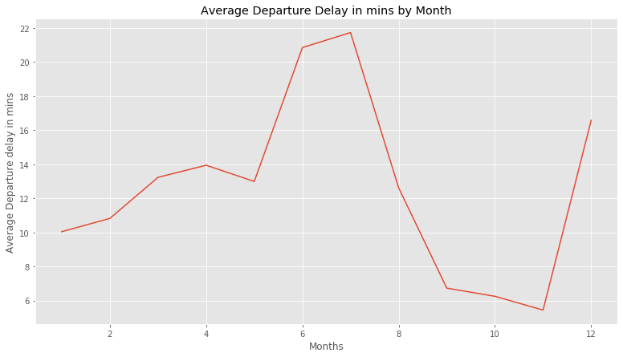

```python
# Your code here

matplotlib.style.use('ggplot')
#Plotting Mean Deaprture Delay by month
plt.plot(flights_df.groupby('month')['dep_delay'].mean())
#Setting the X axis , Y axis and title for the plot
plt.xlabel('Months')
plt.ylabel('Average Departure delay in mins')
plt.title('Average Departure Delay in mins by Month')
plt.show()
```

### (e)

On average, how do departure delays vary over the course of a day?

Ans:

From the plot it is clear that the delays are more prominent during the night mainly between 10 PM and 4 AM (with a peak in the 3rd hour of the day). A possible reason for this could be low visibility condition during these hours or other factors like fog or bad weather conditions. The delay in flight departures go down significantly in other hours of the day.

Also, another point to note is that the number of flights in these late hours are fewer than others -- this is one possible reason why the average of the departure delay times is higher during 10 PM - 4 AM (fewer flights and most flights delayed: Example: Only 11 flights around 3 AM).

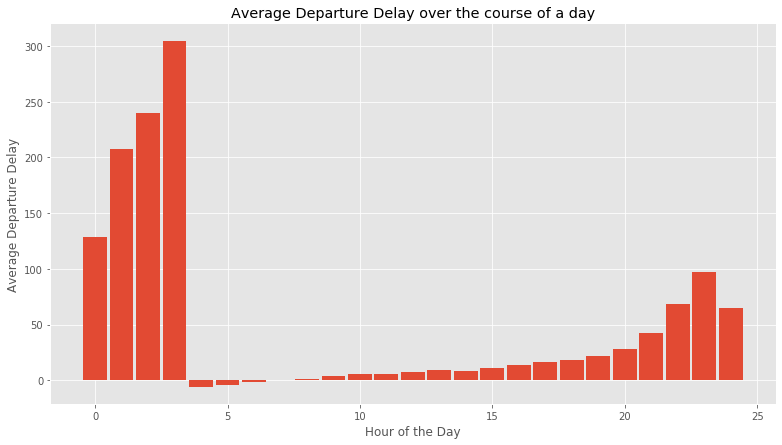

```
Number of flights by hour of the day:
 0.0       881
1.0       223
2.0        64
3.0        11
4.0       305
5.0      7246
6.0     22699
7.0     21461
8.0     26424
9.0     18871
10.0    16076
11.0    16762
12.0    16071
13.0    16890
14.0    20480
15.0    22840
16.0    22336
17.0    22144
18.0    21549
19.0    19940
20.0    16160
21.0    10960
22.0     5483
23.0     2616
24.0       29
Name: Count, dtype: int64
```

```python
# Your code here
# Getting Average Departure delay by hours
flights_dep_delay_by_hour = pd.DataFrame(flights_df.groupby('hour')['dep_delay'].mean())

# Plotting Data
fig, ax = plt.subplots()
plt.bar(range(25), flights_dep_delay_by_hour.dep_delay, 0.90)
#Setting the X axis , Y axis and title for the plot
plt.xlabel('Hour of the Day')
plt.ylabel('Average Departure Delay')
plt.title('Average Departure Delay over the course of a day')
plt.show()

# Calculating the number of flights by hour of the day
count_flights_hour = flights_df.groupby('hour').count()
count_flights_hour.rename(columns={'Unnamed: 0': 'Count'}, inplace=True)
count_flights_hour.index.name = None
print ('Number of flights by hour of the day:\n', count_flights_hour['Count'])
```

## Question 3

Which flight departing NYC in 2013 flew the slowest?

Note: compute the speed as distance/time.

Ans: We will calculate the speed in units - miles per hour.

The following flight from NYC was slowest in 2013 :

Date carrier tailnum flight origin dest air_time distance flight_speed_mph 24098 2013-1-28 US N755US 1860 LGA PHL 75.0 96 76.8

```python
# Your code here

#creating a new column to store the speed of the flights
flights_df['flight_speed_mph'] = flights_df.distance/(flights_df.air_time/60)

#Getting onlt important fields
flights_subset = ['Date','carrier','tailnum','flight','origin','dest','air_time','distance','flight_speed_mph']

# Getting the flight details which flew slowest
print("The following flight from NYC was slowest in 2013 :\n")

flights_df.sort_values('flight_speed_mph',ascending = True)[flights_subset].head(1)
```

```
The following flight from NYC was slowest in 2013 :
```

|  | Date | carrier | tailnum | flight | origin | dest | air_time | distance | flight_speed_mph |
| --- | --- | --- | --- | --- | --- | --- | --- | --- | --- |
| 24098 | 2013-1-28 | US | N755US | 1860 | LGA | PHL | 75.0 | 96 | 76.8 |

## Question 4

Which flights (i.e. carrier + flight + dest) happen every day? Where do they fly to?

Ans:

For a flight to fly every day, it needs to fly these number of days: 365

The flights (i.e. carrier + flight + dest) that happen every day are: ( UA 15 HNL , B6 371 FLL , AA 181 LAX , B6 219 CLT , AA 119 LAX , B6 703 SJU , DL 2391 TPA , AA 1357 SJU , EV 5712 IAD , VX 251 LAS , AA 1611 MIA , VX 413 LAX , DL 2159 MCO , B6 431 SRQ , VX 407 LAX , AA 59 SFO , B6 1783 MCO , B6 359 BUR)

The flights that fly every day fly to the following destinations : ('IAD', 'SRQ', 'SJU', 'CLT', 'SFO', 'HNL', 'LAS', 'MIA', 'BUR', 'MCO', 'FLL', 'LAX', 'TPA')

```python
# Your code here
flights_df['flight_combo_grp'] = flights_df['carrier'].astype(str) + ' ' + flights_df['flight'].astype(str) + ' ' + flights_df['dest'].astype(str)
flights_df.head()


# Getting the unique dates that are present in the dataset and getting a count
dates = pd.DataFrame(flights_df.Date.unique())
dates.rename(columns={0:'Date'}, inplace = True)
total_no_of_Days = dates.Date.count()
print ("\nFor a flight to fly every day, it needs to fly these number of days: ", total_no_of_Days )

# Grouping by flight and date to see which flights fly on which days of the year
flights_date_grp = flights_df.groupby(['flight_combo_grp','Date']).count()
# Getting rid of the flight_combo index from the dataframe
flights_date_grp.reset_index(level=0, inplace=True)
# Getting rid of the date index from the dataframe
flights_date_grp.reset_index(level=0, inplace=True)
flights_date_grp.rename(columns={'Unnamed: 0':'Count'}, inplace = True)

# Getting the count of number of days a particular flight group flies
flights_date_grp = flights_date_grp.groupby('flight_combo_grp').count().sort_values('Count', ascending = False)
flights_date_grp.reset_index(level=0, inplace=True)

# Getting only flights that fly on all days (365 unique days of the current dataset)
flights_all_days = flights_date_grp[flights_date_grp['Count'] == total_no_of_Days]['flight_combo_grp']
print ("\nThe flights (i.e. carrier + flight + dest) that happen every day are: \n")
print(flights_all_days)

# Getting the destinations of the flights happening everyday
destinations = []
for flight in flights_all_days.astype(str):
    destinations.append(flight[len(flight)-3:])
destinations = set(destinations)
print ("\nThe flights that fly every day fly to the following destinations : \n\n")
print(destinations)
```

```
For a flight to fly every day, it needs to fly these number of days:  365

The flights (i.e. carrier + flight + dest) that happen every day are:

0       UA 15 HNL
1      B6 371 FLL
2      AA 181 LAX
3      B6 219 CLT
4      AA 119 LAX
5      B6 703 SJU
6     DL 2391 TPA
7     AA 1357 SJU
8     EV 5712 IAD
9      VX 251 LAS
10    AA 1611 MIA
11     VX 413 LAX
12    DL 2159 MCO
13     B6 431 SRQ
14     VX 407 LAX
15      AA 59 SFO
16    B6 1783 MCO
17     B6 359 BUR
Name: flight_combo_grp, dtype: object

The flights that fly every day fly to the following destinations :


{'IAD', 'SRQ', 'SJU', 'CLT', 'SFO', 'HNL', 'LAS', 'MIA', 'BUR', 'MCO', 'FLL', 'LAX', 'TPA'}
```

## Question 5

Develop one research question you can address using the nycflights2013 dataset. Provide two visualizations to support your exploration of this question. Discuss what you find.

Note: we'll using matplotlib for plotting in this course, but you can use something else too.

Ans : The research question is:

"In 2013, which airlines and airports were best enablers of positive experience for NY flyers and how can users make smarter decisions for better traveling experiences to speicific destinations in the future ?"

Lets assume the user's Positive experience is defined by a user's experience with an airline or an airport depedning on the factors - depature delays, arrival delays, covering more distance in less time (higher speed), etc.

Observations:

1. Best Airports for NY Flyers: The first plot shows the best destinations to travel to from NY based on the delays in arrival, depature and also the number of flights operating. From Graph ,we can see that :

   ```
     - The top 5 destinations to travel to: LEX, PSP, SNA, STT, ANC
     - The worst 5 destinations to travel to: TYS, JAC, OKC, TUL, CAE
   ```

2. Best Carriers overall: The second plot shows the carriers that operate flights from NY to different destinations. We look at aggregate data to see which carriers have the best performance in the least departure delays, least arrival delays and also the avg speed and the total number of flights. From Graph ,we can see that:

   ```
     - The top 5 carriers to fly with: US, HA, AS, AA, DL
     - The worst carriers to fly with: WN, FL, YV, EV, F9
   ```

Note: We assume that the positive experience of the flyer only depends on arrival and departure delays, while there might be a lot of other factors to define customer experience when flying with an airline to a specific destination.

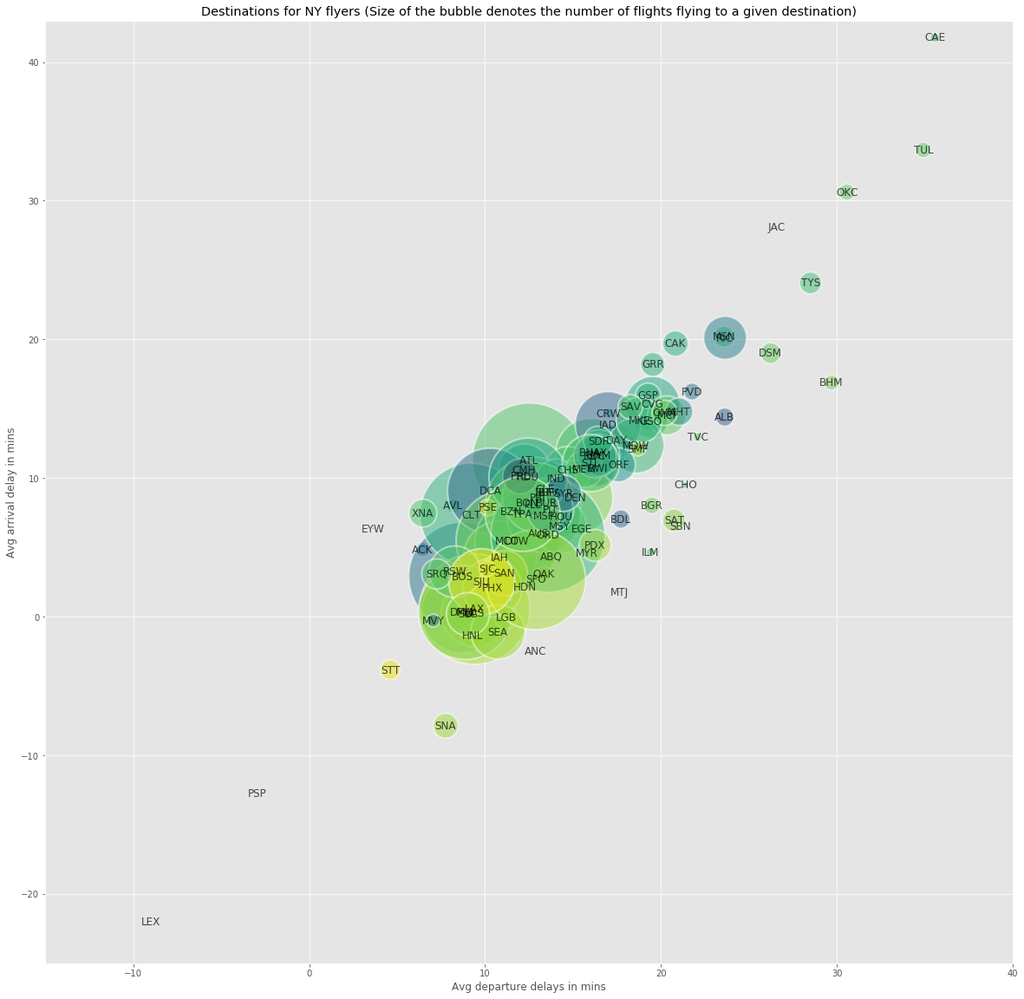

```
The top 5 destinations to travel to:

    dest  dep_delay  arr_delay  flight_speed_mph  total_flights_count
50  LEX  -9.000000 -22.000000        402.666667                    1
77  PSP  -2.944444 -12.722222        429.749501                   19
95  SNA   7.761905  -7.868227        445.110140                  825
98  STT   4.613900  -3.835907        479.149702                  522
3   ANC  12.875000  -2.500000        489.985945                    8


The worst 5 destinations to travel to:

     dest  dep_delay  arr_delay  flight_speed_mph  total_flights_count
103  TYS  28.493955  24.069204        394.902170                  631
46   JAC  26.545455  28.095238        426.336973                   25
67   OKC  30.568807  30.619048        415.679642                  346
101  TUL  34.906355  33.659864        412.419982                  315
18   CAE  35.570093  41.764151        391.462917                  116
```

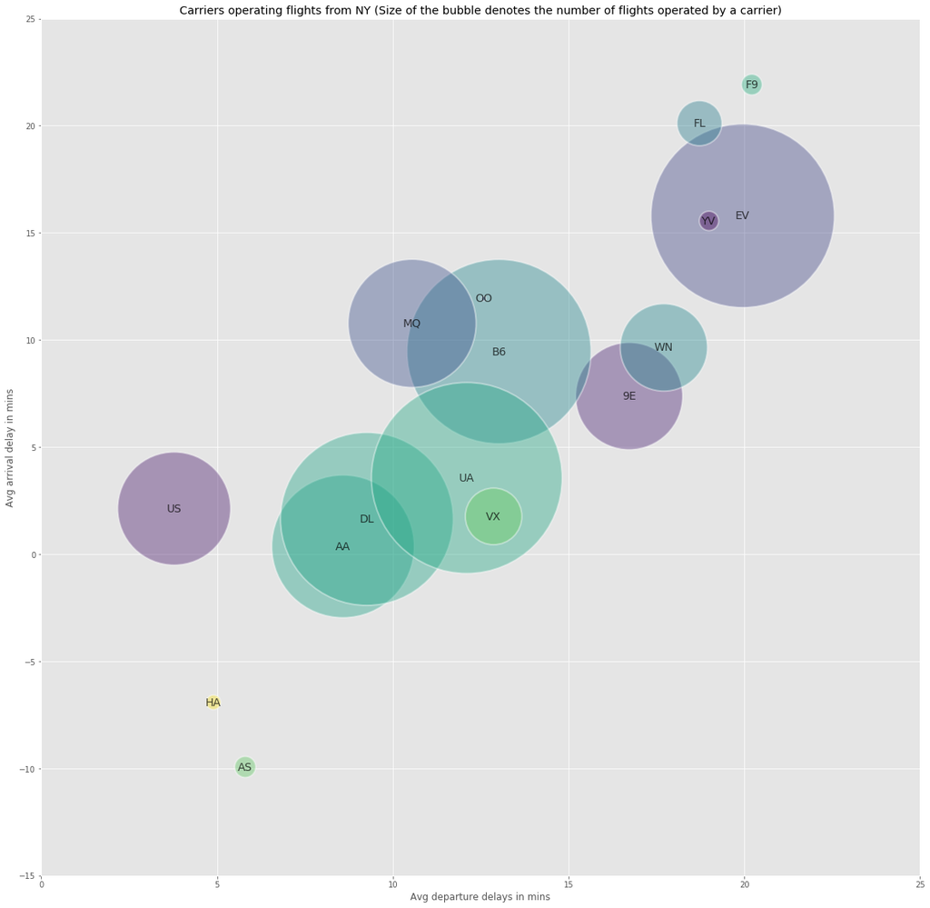

```
The top 5 carriers to travel with:

    carrier  dep_delay  arr_delay  flight_speed_mph  total_flights_count
12      US   3.782418   2.129595        341.939717                20536
8       HA   4.900585  -6.915205        480.357719                  342
2       AS   5.804775  -9.930889        443.678889                  714
1       AA   8.586016   0.364291        417.472739                32729
4       DL   9.264505   1.644341        418.462807                48110


The worst 5 carriers to travel with:

    carrier  dep_delay  arr_delay  flight_speed_mph  total_flights_count
14      WN  17.711744   9.649120        400.532009                12275
7       FL  18.726075  20.115906        394.358094                 3260
15      YV  18.996330  15.556985        331.969987                  601
5       EV  19.955390  15.796431        362.943626                54173
6       F9  20.215543  21.920705        425.172111                  685

For flying to the specific destination from NY, its in the best interest of the user to select the right carrier!

The least time lost (departure delay + arrival delay) ensures the user has best experience with a specific carrier to a specific destination.

The table below shows users the best airline to pick while traveling to the one of the 105 destinations from NY:


    best_carrier dest  avg_time_lost
126           UA  IAD     -34.000000
152           9E  LEX     -31.000000
25            DL  BNA     -31.000000
132           DL  IND     -29.000000
295           DL  STT     -25.206897
..           ...  ...            ...
53            FL  CAK      40.543943
23            EV  BHM      45.892193
194           EV  OKC      59.800000
307           EV  TUL      68.547619
153           US  LGA            NaN

[105 rows x 3 columns]
```

```python
# Your code here

#Exploring first part of the research question -- what are the best destinations to fly from NYC

# Finding the destination statistics
dest_avgs = flights_df.groupby('dest')['dep_delay','arr_delay','flight_speed_mph'].mean()
dest_avgs.reset_index(level=0, inplace=True)

# Cleaning up data further
total_flights = flights_df.groupby('dest').count()
total_flights.reset_index(level=0, inplace=True)
total_flights.rename(columns = {'Unnamed: 0':'Count'}, inplace = True)
dest_avgs['total_flights_count'] = total_flights['Count']
dest_avgs = dest_avgs[np.isfinite(dest_avgs['dep_delay'])]
dest_avgs = dest_avgs[np.isfinite(dest_avgs['arr_delay'])]
dest_avgs = dest_avgs[np.isfinite(dest_avgs['flight_speed_mph'])]

rcParams['figure.figsize'] = 20, 20

# Preparing for plotting
x = list(dest_avgs['dep_delay']) # X axis shows the departure delay in mins
y = list(dest_avgs['arr_delay']) # Y axis shows the arrival delay in mins
color = list(dest_avgs['flight_speed_mph']) # The color of the bubbles show the speed of the flights
area = list(dest_avgs['total_flights_count']) # The size of the bubbles show the number of flights to that destination
s = list(dest_avgs['dest'])

i = 0
while(i<len(dest_avgs)):
    text(x[i],y[i],s[i],size=12, verticalalignment='center', horizontalalignment='center', color='black', alpha = 0.7)
    i = i+1

sct = scatter(x, y, c=color, s=area, linewidths=2, edgecolor='w')
sct.set_alpha(0.50)

axis([-15,40,-25,43])
xlabel('Avg departure delays in mins')
ylabel('Avg arrival delay in mins')
title('Destinations for NY flyers (Size of the bubble denotes the number of flights flying to a given destination)')

show()

print("The top 5 destinations to travel to:\n\n", dest_avgs.sort_values(['arr_delay','dep_delay']).head(5))
print("\n\nThe worst 5 destinations to travel to:\n\n", dest_avgs.sort_values(['arr_delay','dep_delay']).tail(5))


# Exploring the second part of the research question, what are the best airlines to fly with

# Finding the carrier statistics
carrier_avgs = flights_df.groupby('carrier')['dep_delay','arr_delay','flight_speed_mph'].mean()
carrier_avgs.reset_index(level=0, inplace=True)

# Cleaning up data further
total_flights_ca = flights_df.groupby('carrier').count()
total_flights_ca.reset_index(level=0, inplace=True)
total_flights_ca.rename(columns = {'Unnamed: 0':'count'}, inplace = True)
carrier_avgs['total_flights_count'] = total_flights_ca['count']
carrier_avgs = carrier_avgs[np.isfinite(carrier_avgs['dep_delay'])]
carrier_avgs = carrier_avgs[np.isfinite(carrier_avgs['arr_delay'])]
carrier_avgs = carrier_avgs[np.isfinite(carrier_avgs['flight_speed_mph'])]


# Preparing for plotting
x2 = list(carrier_avgs['dep_delay']) # X axis shows the departure delay in mins
y2 = list(carrier_avgs['arr_delay']) # Y axis shows the arrival delay in mins
color2 = list(carrier_avgs['flight_speed_mph']) # The color of the bubbles show the speed of the flights
area2 = list(carrier_avgs['total_flights_count']) # The size of the bubbles show the number of flights to that destination
s2 = list(carrier_avgs['carrier'])

i = 0
while(i<len(carrier_avgs)):
    text(x2[i],y2[i],s2[i],size=14, verticalalignment='center', horizontalalignment='center', color='black', alpha = 0.7)
    i = i+1

sct2 = scatter(x2, y2, c=color2, s=area2, linewidths=2, edgecolor='w')
sct2.set_alpha(0.4)
rcParams['figure.figsize'] = 20, 20

axis([0,25,-15,25])
xlabel('Avg departure delays in mins')
ylabel('Avg arrival delay in mins')
title('Carriers operating flights from NY (Size of the bubble denotes the number of flights operated by a carrier)')

show()

print ("\nThe top 5 carriers to travel with:\n\n", carrier_avgs.sort_values(['dep_delay','arr_delay']).head(5))
print ("\n\nThe worst 5 carriers to travel with:\n\n", carrier_avgs.sort_values(['dep_delay','arr_delay']).tail(5))



flights_df['avg_time_lost'] = flights_df['arr_delay']+flights_df['dep_delay']
best_combination = pd.DataFrame(flights_df.groupby(['dest','carrier'])['avg_time_lost'].mean())
best_combination.reset_index(level=0, inplace=True)
best_combination.reset_index(level=0, inplace=True)
best_combination = best_combination.sort_values('avg_time_lost')
best_combination.rename(columns = {'carrier':'best_carrier'}, inplace = True)
print ("\nFor flying to the specific destination from NY, its in the best interest of the user to select the right carrier!\n")
print ("The least time lost (departure delay + arrival delay) ensures the user has best experience with a specific carrier to a specific destination. \n ")
print ("The table below shows users the best airline to pick while traveling to the one of the 105 destinations from NY:\n\n")
print (best_combination.drop_duplicates(subset='dest', keep='first'))
```

## Question 6

What weather conditions are associated with flight delays leaving NYC? Use graphics to explore.

Note: you need to use 'weather.csv' dataset

Ans : Here, we are trying to study effect of different weather conditions on flight delays. We can see how a variety of weather conditions have an effect on the flights' departure delay.

The first plot shows that as visibility increases, the departure delay in turn decreases. Thus by analyzing such parameters, we can predict if a flight will be delayed or not.

The second plot shows the relation between wind speed and departure delay. We see that as the wind speed increases, the departure delays increase.

The third plot shows the correlation between temperature and departure delay, We can see that as the temperature increases, the departure delay decreases but then increase again as temperatures get really high. Thus in lower and extremely high temperatures, the chances of flights being delayed are higher.

The fourth plot shows the relationship between wind direction and departure delay. We can see a sinosoidal pattern in the graph where the delays increase as the wind direction increases slightly and then decrease again.

The fifth plot represents the correlation between dew and departure delays. We can see that there is not a very strong correlation between the 2, but as dew increases there is a slight increase in the departure delay

Similarly from the other plots, we can see the affect of different weather conditions on Departure Delay.

In the second analysis , we are trying to see the affect of temperature, visibility and precipitation on the Departure Delay.

From the bubble chart, its clear that the months of December, June and July had the highest departure delays. The month of June had most precipitation (the area of bubble denotes the precipitation levels), July had the highest temperature and December had low temperatures and good precipitation.

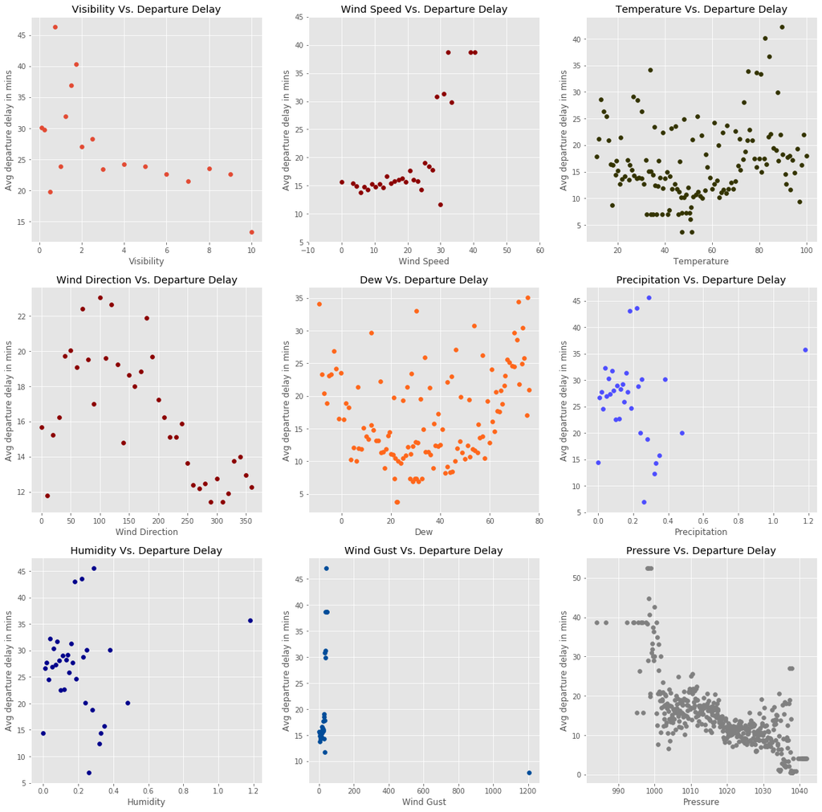

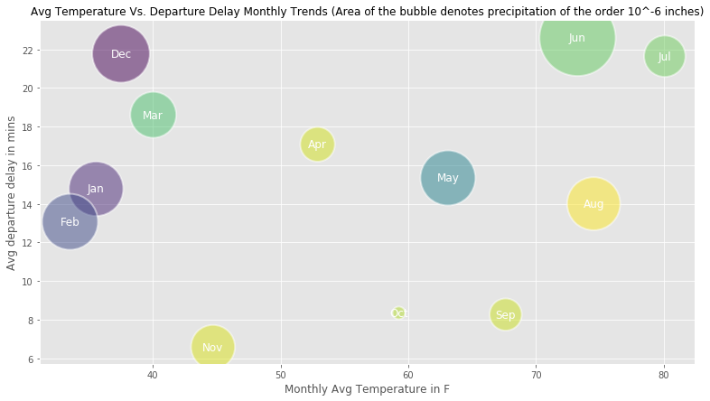

```python
# Getting the weather dataset
weather_df = pd.read_csv('C:/Users/vaide/Documents/574-DS2/weather.csv.bz2')

# Keeping only the useful columns of weather dataframe
weather_df =  pd.DataFrame(weather_df[['origin','year','month','day','temp','dewp','humid','wind_dir',
                                       'wind_speed','wind_gust','precip','pressure','visib']])

# Keeping only useful columns of  flights dataframe
flights_sub = flights_df[['origin','year','month','day','dep_delay','arr_delay','flight_speed_mph']]

#Joining it with flights dataset
flight_weather = pd.merge(weather_df, flights_sub, how='inner', on=['year', 'month', 'day', 'origin'])

#Plot between visibility and departure delay
df2=pd.DataFrame(flight_weather.groupby('visib')['dep_delay'].mean())
matplotlib.style.use('ggplot')
rcParams['figure.figsize'] = 20, 20
fig = plt.figure()
ax1 = fig.add_subplot(331)
df2['visib'] = df2.index
ax1.scatter(df2['visib'],df2['dep_delay'])
xlabel('Visibility')
ylabel('Avg departure delay in mins')
title('Visibility Vs. Departure Delay')

#Plot between wind speed and departure delay
ax2 = fig.add_subplot(332)
df2=pd.DataFrame(flight_weather.groupby('wind_speed')['dep_delay'].mean())
df2['wind_speed'] = df2.index
ax2.scatter(df2['wind_speed'],df2['dep_delay'], c = 'darkred')
axis([-10,60,5,45])
xlabel('Wind Speed')
ylabel('Avg departure delay in mins')
title('Wind Speed Vs. Departure Delay')

#Plot between Temperature and departure delay
ax3 = fig.add_subplot(333)
df2=pd.DataFrame(flight_weather.groupby('temp')['dep_delay'].mean())
df2['temp'] = df2.index
ax3.scatter(df2['temp'],df2['dep_delay'], c = '#333300')
xlabel('Temperature')
ylabel('Avg departure delay in mins')
title('Temperature Vs. Departure Delay')

#Plot between wind direction and departure delay
ax4 = fig.add_subplot(334)
df2=pd.DataFrame(flight_weather.groupby('wind_dir')['dep_delay'].mean())
df2['wind_dir'] = df2.index
ax4.scatter(df2['wind_dir'],df2['dep_delay'], c = 'darkred')
xlabel('Wind Direction')
ylabel('Avg departure delay in mins')
title('Wind Direction Vs. Departure Delay')

#Plot between Dew and departure delay
ax5 = fig.add_subplot(335)
df2=pd.DataFrame(flight_weather.groupby('dewp')['dep_delay'].mean())
df2['dewp'] = df2.index
ax5.scatter(df2['dewp'],df2['dep_delay'], c = '#ff661a')
xlabel('Dew')
ylabel('Avg departure delay in mins')
title('Dew Vs. Departure Delay')

#Plot between Precipitation and departure delay
ax6 = fig.add_subplot(336)
df2=pd.DataFrame(flight_weather.groupby('precip')['dep_delay'].mean())
df2['precip'] = df2.index
ax6.scatter(df2['precip'],df2['dep_delay'], c = '#4d4dff')
xlabel('Precipitation')
ylabel('Avg departure delay in mins')
title('Precipitation Vs. Departure Delay')

#Plot between Humidiy and departure delay
ax7 = fig.add_subplot(337)
df2=pd.DataFrame(flight_weather.groupby('precip')['dep_delay'].mean())
df2['humid'] = df2.index
ax7.scatter(df2['humid'],df2['dep_delay'], c = 'darkblue')
xlabel('Humidity')
ylabel('Avg departure delay in mins')
title('Humidity Vs. Departure Delay')

#Plot between Wind Gust and departure delay
ax8 = fig.add_subplot(338)
df2=pd.DataFrame(flight_weather.groupby('wind_gust')['dep_delay'].mean())
df2['wind_gust'] = df2.index
ax8.scatter(df2['wind_gust'],df2['dep_delay'], c = '#004c99')
xlabel('Wind Gust')
ylabel('Avg departure delay in mins')
title('Wind Gust Vs. Departure Delay')

#Plot between Pressure and departure delay
ax9 = fig.add_subplot(339)
df2=pd.DataFrame(flight_weather.groupby('pressure')['dep_delay'].mean())
df2['pressure'] = df2.index
ax9.scatter(df2['pressure'],df2['dep_delay'], c = 'grey')
xlabel('Pressure')
ylabel('Avg departure delay in mins')
title('Pressure Vs. Departure Delay')


flights_weather_agg = flight_weather.groupby(['year','month','day','origin']).mean()
flights_weather_agg.reset_index(level = 0, inplace = True)
flights_weather_agg.reset_index(level = 0, inplace = True)
flights_weather_agg.reset_index(level = 0, inplace = True)
flights_weather_agg.reset_index(level = 0, inplace = True)

# Grouping by month to see the patterns by months
flights_weather_month = flights_weather_agg.groupby('month').mean()
flights_weather_month.reset_index(level=0, inplace = True)
flights_weather_month['precip'] = flights_weather_month['precip'] * 1000000

# Preparing for plotting the seasional month pattern
x = list(flights_weather_month['temp'])
y = list(flights_weather_month['dep_delay'])
color = list(flights_weather_month['visib'])
area = list(flights_weather_month['precip'])
months = ['Jan','Feb','Mar','Apr','May','Jun','Jul','Aug','Sep','Oct','Nov','Dec']

matplotlib.style.use('ggplot')

rcParams['figure.figsize'] = 13, 7
fig2 = plt.figure()

ax1 = fig2.add_subplot(111)
ax1.scatter(x, y, c=color, s=area, linewidths=2, edgecolor='w',alpha = 0.5, label = 'Trends')
i = 0
while(i<len(flights_weather_month)):
    text(x[i],y[i],months[i],size=12, verticalalignment='center', horizontalalignment='center', color='white')
    i = i+1
xlabel('Monthly Avg Temperature in F')
ylabel('Avg departure delay in mins')
title('Avg Temperature Vs. Departure Delay Monthly Trends (Area of the bubble denotes precipitation of the order 10^-6 inches)', size = 12)
show()
```

# Grading

- Q1: 1pt each question (5 in total)
- Q2: a) 2pt, b) 3pt, c) 2pt, d) 2pt, e) 1pt
- Q3: 5pt
- Q4: 5pt
- Q5: 15pt
- Q6: 10pt